# Ford GoBike System Data

# 1- Preprocessing

```python
print ('There are {0} features, and {1} Observations in the dataset'.format(df.shape[1], df.shape[0]))
```

```
There are 16 features, and 183412 Observations in the dataset
```

## 1.1 Check for Null Values

```python
df.info(null_counts = 1)
```

```
<class 'pandas.core.frame.DataFrame'>
RangeIndex: 183412 entries, 0 to 183411
Data columns (total 16 columns):
 #   Column                   Non-Null Count   Dtype
---  ------                   --------------   -----
 0   duration_sec             183412 non-null  int64
 1   start_time               183412 non-null  object
 2   end_time                 183412 non-null  object
 3   start_station_id         183215 non-null  float64
 4   start_station_name       183215 non-null  object
 5   start_station_latitude   183412 non-null  float64
 6   start_station_longitude  183412 non-null  float64
 7   end_station_id           183215 non-null  float64
 8   end_station_name         183215 non-null  object
 9   end_station_latitude     183412 non-null  float64
 10  end_station_longitude    183412 non-null  float64
 11  bike_id                  183412 non-null  int64
 12  user_type                183412 non-null  object
 13  member_birth_year        175147 non-null  float64
 14  member_gender            175147 non-null  object
 15  bike_share_for_all_trip  183412 non-null  object
dtypes: float64(7), int64(2), object(7)
memory usage: 22.4+ MB
```

```python
# Start Stations and End stations
display(df2.describe(include=np.object))
```

|  | start_station_name | end_station_name | bike_share_for_all_trip |
| --- | --- | --- | --- |
| count | 174952 | 174952 | 174952 |
| unique | 329 | 329 | 2 |
| top | Market St at 10th St | San Francisco Caltrain Station 2 (Townsend St... | No |
| freq | 3649 | 4624 | 157606 |

# 2. Data Analysis

## 2.1 Univariate Analysis

### Duration in Seconds & Minutes

```python
df2.duration_sec.describe()
```

```
count    174952.000000
mean        704.002744
std        1642.204905
min          61.000000
25%         323.000000
50%         510.000000
75%         789.000000
max       84548.000000
Name: duration_sec, dtype: float64
```

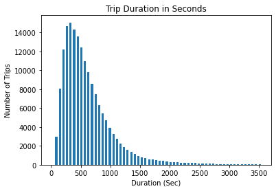

```python
# Duration of the bike rides
bin_edges = np.arange(0, 3600, 60)

plt.hist(data = df2, x = 'duration_sec', bins = bin_edges, rwidth = 0.6);

plt.title("Trip Duration in Seconds")
plt.xlabel('Duration (Sec)')
plt.ylabel('Number of Trips');
```

We could also show the distribution of the duration in minutes

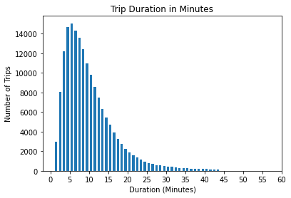

```python
bin_edges = bin_edges = np.arange(0, 45, 1)
plt.hist(data = df2, x = 'duration_min', bins = bin_edges, rwidth = 0.6);
ticks = [0, 5, 10, 15, 20, 25, 30,  35, 40, 45, 50, 55, 60]
plt.xticks(ticks)
plt.title("Trip Duration in Minutes")
plt.xlabel('Duration (Minutes)')
plt.ylabel('Number of Trips');
```

```python
df2.duration_min.describe()
```

```
count    174952.000000
mean         11.733379
std          27.370082
min           1.016667
25%           5.383333
50%           8.500000
75%          13.150000
max        1409.133333
Name: duration_min, dtype: float64
```

```python
df2.duration_min.quantile([.1, .25, .5, .75, .95, .99])
```

```
0.10     3.550000
0.25     5.383333
0.50     8.500000
0.75    13.150000
0.95    25.516667
0.99    52.933333
Name: duration_min, dtype: float64
```

__INSIGHT:__ As shown above, 95% of the data have average tripe time less than 26 minutes, 99% with average trip time less than 53 minutes. While in general the average trip time is about 12 minutes. We still have some extreme values in column (duration_min) but moving forward we focus only with rows that have average trip time less than 60m.

### User Types

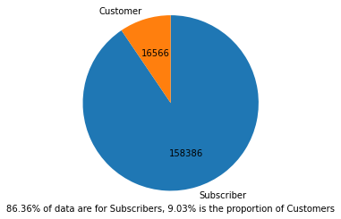

```python
# user type
df2.user_type.unique()
useTypeCounts = df2.user_type.value_counts()
p, tx, autotexts = plt.pie(useTypeCounts, labels=useTypeCounts.index,startangle = 90, counterclock=False, autopct='')

for i, a in enumerate(autotexts):
    a.set_text("{}".format(useTypeCounts[i]))
plt.axis('square')
plt.xlabel('{0:.2f}% of data are for Subscribers, {1:.2f}% is the proportion of Customers'.
           format(
               (useTypeCounts[0] / df.shape[0] * 100),
               (useTypeCounts[1] / df.shape[0] * 100)))
```

__INSIGHT:__ Most of our users are subscribers 86.36%, Customers shares is 9.03%.

### User Gender

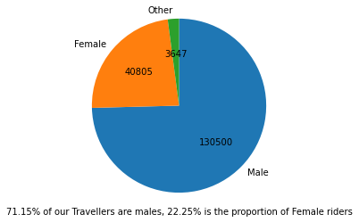

```python
# user type
df2.member_gender.unique()
genderCounts = df2.member_gender.value_counts()
p, tx, autotexts = plt.pie(genderCounts, labels=genderCounts.index,startangle = 90, counterclock=False, autopct='')

for i, a in enumerate(autotexts):
    a.set_text("{}".format(genderCounts[i]))
plt.axis('square')
plt.xlabel('{0:.2f}% of our Travellers are males, {1:.2f}% is the proportion of Female riders'.
           format(
               (genderCounts[0] / df.shape[0] * 100),
               (genderCounts[1] / df.shape[0] * 100)))
```

__INSIGHT:__ Most of our users are Males 71.15%, Female riders represents 22.25% of the dataset.

### When are most trips taken in terms of time of day, day of the week, or month of the year

#### Month of The Year

As it shown in the below, all the records are in February, no distrubtion by month of the year is relevant here

```python
df2.groupby(df2['start_time'].dt.month.astype(int)).count()
```

| start_time | duration_sec | start_time | end_time | start_station_id | start_station_name | start_station_latitude | start_station_longitude | end_station_id | end_station_name | end_station_latitude | end_station_longitude | bike_id | user_type | member_birth_year | member_gender | bike_share_for_all_trip | duration_min |
| --- | --- | --- | --- | --- | --- | --- | --- | --- | --- | --- | --- | --- | --- | --- | --- | --- | --- |
| 2 | 174952 | 174952 | 174952 | 174952 | 174952 | 174952 | 174952 | 174952 | 174952 | 174952 | 174952 | 174952 | 174952 | 174952 | 174952 | 174952 | 174952 |

#### Day of a Month

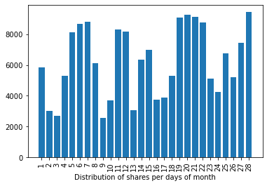

```python
start_times = df2.groupby(df2['start_time'].dt.day).count().start_time
plt.bar(start_times.index, start_times)
plt.xticks(start_times.index, rotation=90)
plt.xlabel('Distribution of shares per days of month')
```

#### Weekday

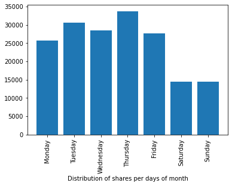

```python
start_times = df2.groupby(df2['start_time'].dt.weekday).count().start_time
days_of_the_week = ['Monday', 'Tuesday', 'Wednesday', 'Thursday', 'Friday', 'Saturday', 'Sunday']
plt.bar(days_of_the_week, start_times)
plt.xticks(days_of_the_week, rotation=90)
plt.xlabel('Distribution of shares per days of month')
```

__INSIGHT:__ As hown above, weekends are have the lowest shares every week

#### Day Hours

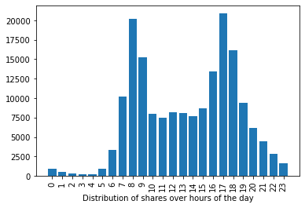

```python
start_times = df2.groupby(df2['start_time'].dt.hour).count().start_time

plt.bar(start_times.index, start_times)
plt.xticks(start_times.index, rotation=90)
plt.xlabel('Distribution of shares over hours of the day')
```

__INSIGHT:__ Morning (7-9 AM) and evening (3-7 PM) rush hours have more data than other hours of the day

## User Age

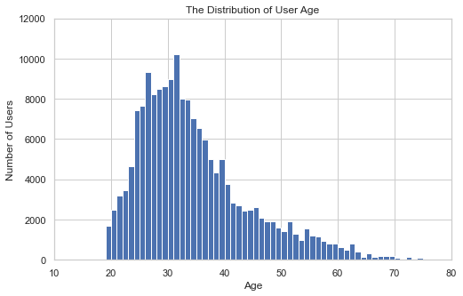

```python
# Use member_birth_year to draw the user's age distribution.
#add column for user age to be used in bivariate analysis
df2['age_years'] = 2019 - df2.member_birth_year

binsize = 1
bins = np.arange(0, df2['member_birth_year'].astype(float).max()+binsize, binsize)

plt.figure(figsize=[8, 5])
plt.hist(data = df2, x = 'age_years', bins = bins)
plt.axis([10, 80, 0, 12000])
plt.title('The Distribution of User Age')
plt.xlabel('Age')
plt.ylabel('Number of Users')
```

```python
df2.age_years.quantile([.10, .2, .5,.75, .9, .95, .99])
```

```
0.10    24.0
0.20    26.0
0.50    32.0
0.75    39.0
0.90    49.0
0.95    55.0
0.99    64.0
Name: member_birth_year, dtype: float64
```

__INSIGHT:__ Most of our users are under Age 60 (95%) and 99% of users are under ager 65.

## 2.1 Bivariate Analysis

|  | duration_sec | start_station_id | start_station_latitude | start_station_longitude | end_station_id | end_station_latitude | end_station_longitude | bike_id | member_birth_year | duration_min |
| --- | --- | --- | --- | --- | --- | --- | --- | --- | --- | --- |
| duration_sec | 1.000000 | -0.006876 | 0.012237 | -0.040946 | 0.002552 | 0.012854 | -0.041438 | 0.011037 | -0.006041 | 1.000000 |
| start_station_id | -0.006876 | 1.000000 | -0.195403 | 0.465130 | 0.339914 | -0.184317 | 0.472373 | -0.068114 | 0.115115 | -0.006876 |
| start_station_latitude | 0.012237 | -0.195403 | 1.000000 | -0.678105 | -0.184497 | 0.990130 | -0.683552 | 0.051140 | -0.075238 | 0.012237 |
| start_station_longitude | -0.040946 | 0.465130 | -0.678105 | 1.000000 | 0.485894 | -0.682598 | 0.992507 | -0.144058 | 0.125346 | -0.040946 |
| end_station_id | 0.002552 | 0.339914 | -0.184497 | 0.485894 | 1.000000 | -0.202501 | 0.475503 | -0.056796 | 0.112709 | 0.002552 |
| end_station_latitude | 0.012854 | -0.184317 | 0.990130 | -0.682598 | -0.202501 | 1.000000 | -0.685085 | 0.050507 | -0.075339 | 0.012854 |
| end_station_longitude | -0.041438 | 0.472373 | -0.683552 | 0.992507 | 0.475503 | -0.685085 | 1.000000 | -0.145895 | 0.126191 | -0.041438 |
| bike_id | 0.011037 | -0.068114 | 0.051140 | -0.144058 | -0.056796 | 0.050507 | -0.145895 | 1.000000 | 0.036226 | 0.011037 |
| member_birth_year | -0.006041 | 0.115115 | -0.075238 | 0.125346 | 0.112709 | -0.075339 | 0.126191 | 0.036226 | 1.000000 | -0.006041 |
| duration_min | 1.000000 | -0.006876 | 0.012237 | -0.040946 | 0.002552 | 0.012854 | -0.041438 | 0.011037 | -0.006041 | 1.000000 |

[output not shown]

[output cut: 46 more lines]

[output not shown]

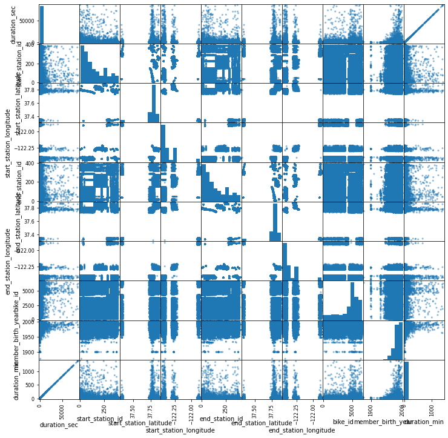

```python
display(df2.corr())
pd.plotting.scatter_matrix(df2, figsize=(12, 12))
```

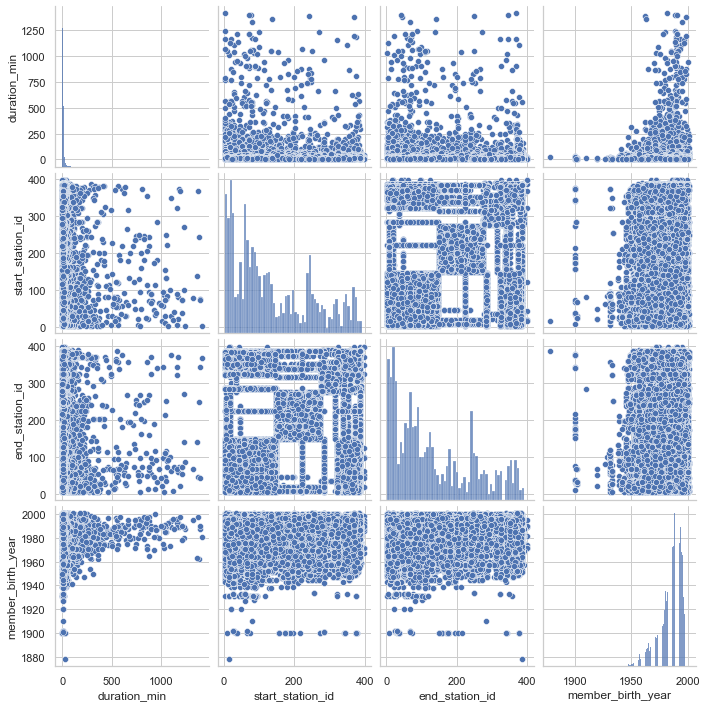

```python
sb.set(style="whitegrid", context="notebook")
sb.pairplot(df2[["duration_min", "start_station_id",
                        "end_station_id","member_birth_year"]])
```

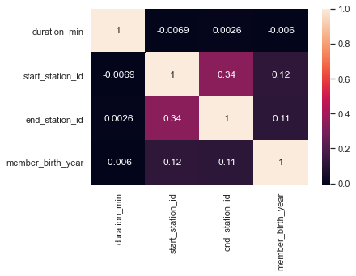

```python
corr = df2[["duration_min", "start_station_id",
                        "end_station_id","member_birth_year"]].corr()
corr
ax = sb.heatmap(corr, annot=True,)
```

### Check if duration in minutes is related to the user Age

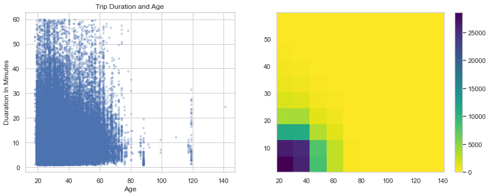

```python
# as mentioned earlier we focus only on trips with duration in minutes less than 60m (avoid extreme values)
df3 = df2[df2.duration_min < 60]
plt.figure(figsize=[14,5])
plt.subplot(1, 2, 1)
plt.scatter(df3.age_years, df3.duration_min, alpha = 0.25, marker = '.' )
plt.title('Trip Duration and Age')
plt.xlabel('Age')
plt.ylabel('Duaration In Minutes')

plt.subplot(1, 2, 2)
bins_y  = np.arange(200, 1250+50, 50)
bins_x = np.arange(-5, 85+1, 10)
plt.hist2d(df3.age_years, df3.duration_min, cmap='viridis_r')
plt.colorbar();
#250-1250
```

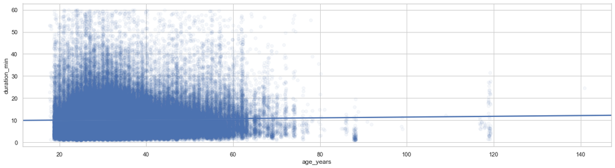

```python
plt.figure(figsize = [20, 5])

sb.regplot(data = df3, x = 'age_years', y = 'duration_min', truncate=False, x_jitter=0.3, scatter_kws={'alpha':1/20});
```

### Relation between trip duration and member gender

[figure not shown]

```python
plt.figure(figsize = [10, 5])
base_color = sb.color_palette()[0]
sb.boxplot(data = df3, x = 'member_gender', y = 'duration_min', color = base_color)
#plt.ylim([-10, 2000])
plt.title('Trip Duration and Gender')
plt.xlabel('Gender')
plt.ylabel('Duration In Minutes')
```

__INSIGHT:__ The trip duration in minutes for femal and other is higher than male users.

## 2.3 Multivariate Exploration

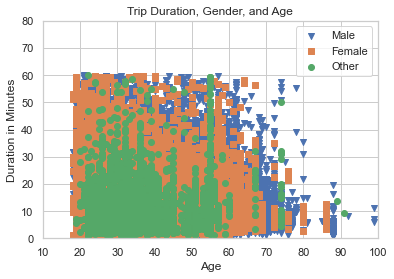

```python
markers = [['Male', 'v'],['Female', 's'],['Other', 'o']]

for gender, marker in markers:
    df_gender = df3[df3['member_gender'] == gender]
    plt.scatter(df_gender.age_years, df_gender.duration_min, marker = marker, alpha= 1)
plt.legend(['Male','Female','Other'])
plt.axis([10, 100, 0, 80 ])
plt.title('Trip Duration, Gender, and Age')
plt.xlabel('Age')
plt.ylabel('Duration in Minutes')
```

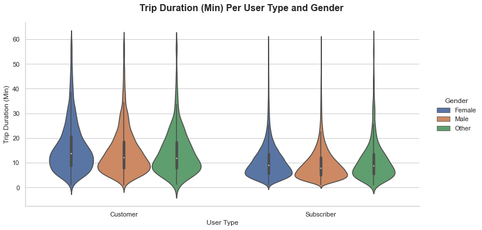

```python
# Duration (min) per user type and gender

graph = sb.catplot(data=df3, x='user_type', y="duration_min", hue="member_gender", kind="violin", height=5, aspect=2);

graph.set_axis_labels("User Type", "Trip Duration (Min)")
graph._legend.set_title('Gender')
graph.fig.suptitle('Trip Duration (Min) Per User Type and Gender', y=1.05, fontsize=16, fontweight='bold');
```

__INSIGHT:__ For Vustomer, and Subscribers, female users tend to have higher average trip time